# Lab3

Matthew McCaskey, Mitchell Holman, Tucker Southern

9/7/2017

1. Create and describe the time series plot of the ‘Trade.csv‘ data located at the Data Sets folder in AsULearn. This data set contains monthly employment data (number of people employed) in trade industries in one city. Call this data Yt.

```r
library(readr)
Y <- read.csv("/home/students/holmanma/TS/Time_S/ts/Trade.csv")
Y
```

```
##    Trade
## 1    322
## 2    317
## 3    319
## 4    323
## 5    327
## 6    328
## 7    325
## 8    326
## 9    330
## 10   334
## 11   337
## 12   341
## 13   322
## 14   318
```

[output cut: 46 more lines]

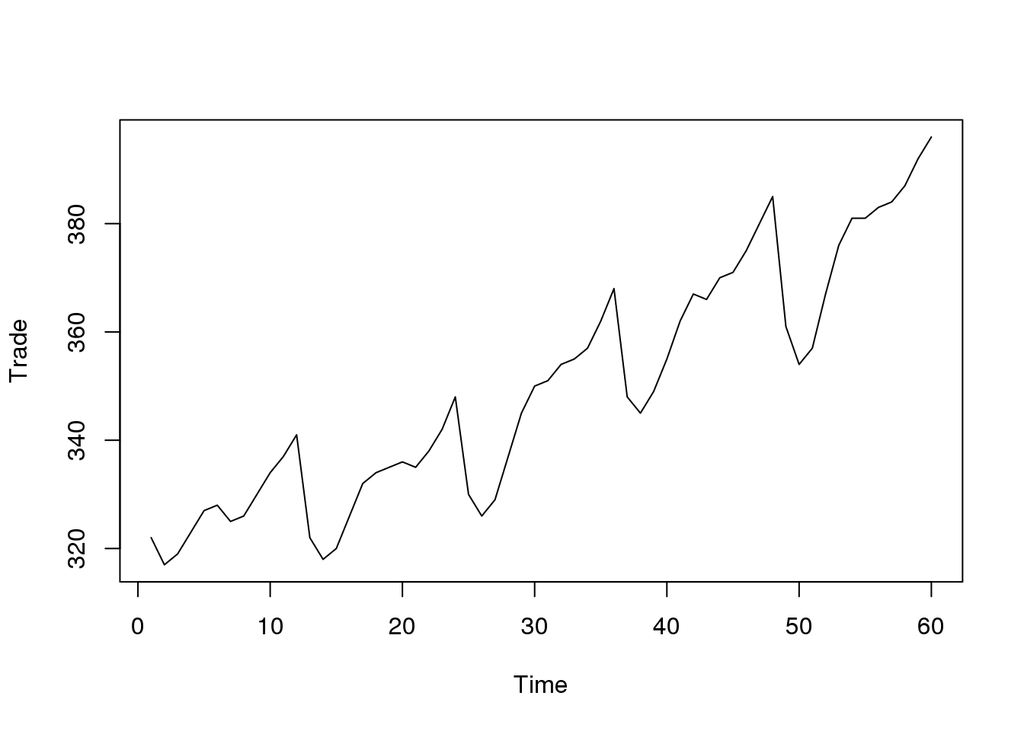

```r
yt <- ts(Y)
plot.ts(yt)
```

**The time series shows an overall increasing trend with seasonality.**

2. Fit a simple linear regression trend model to the trade data. Interpret the estimates of the intercept and slope in context.

```r
t <- 1:60
mod1 <- lm(yt ~ t)
summary(mod1)
```

```
##
## Call:
## lm(formula = yt ~ t)
##
## Residuals:
##     Min      1Q  Median      3Q     Max
## -18.275  -5.844   1.720   5.469  15.098
##
## Coefficients:
##              Estimate Std. Error t value Pr(>|t|)
## (Intercept) 313.98870    2.18375  143.78   <2e-16 ***
## t             1.16485    0.06226   18.71   <2e-16 ***
## ---
## Signif. codes:  0 '***' 0.001 '**' 0.01 '*' 0.05 '.' 0.1 ' ' 1
##
## Residual standard error: 8.352 on 58 degrees of freedom
## Multiple R-squared:  0.8579, Adjusted R-squared:  0.8554
## F-statistic:   350 on 1 and 58 DF,  p-value: < 2.2e-16
```

3. Is there a statistically significant evidence to reject the null hypothesis that the slope of the model is 0? Explain. **There is evidence that suggests we should reject the null hypothesis as the p-value of the model is nearly 0,** **well below the .05 threshold.**
4. Obtain the de-trended trade data then create and describe the time series plot of the de-trended trade data. (Hint: the de-trended data are the residuals after fitting the simple linear regression model in #2). Call the de-trended data Dt. Is Dt a white noise? Justify by attaching and discussing its correlogram.

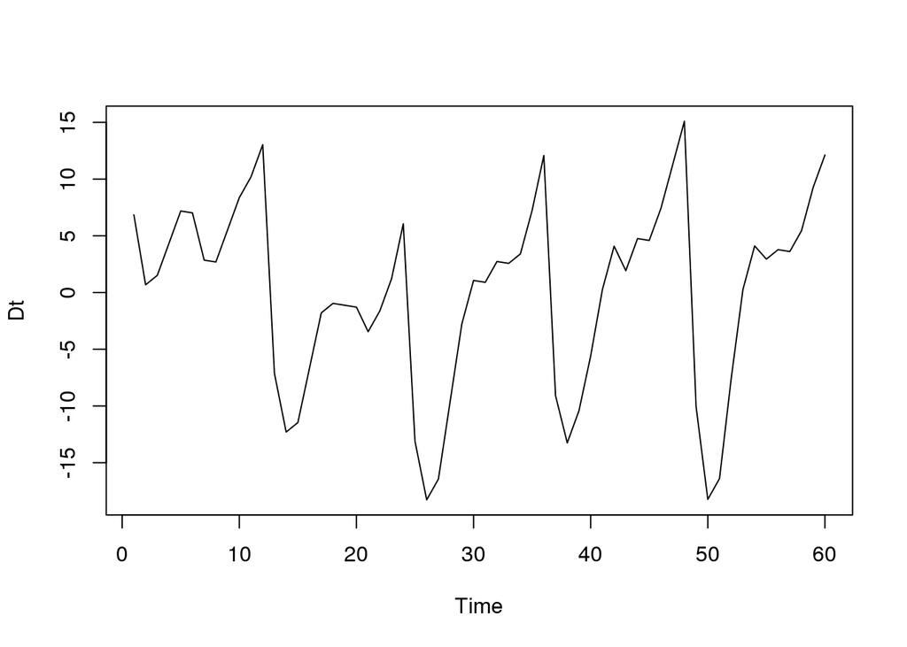

```r
res <- mod1$residuals
Dt <- ts(res)
plot.ts(Dt)
```

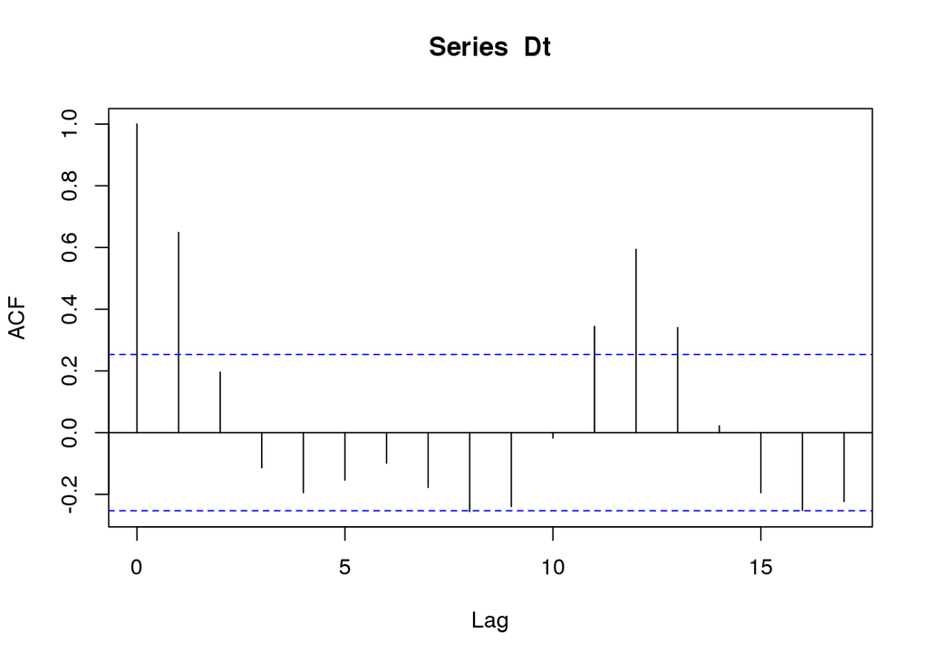

```r
acf(Dt)
```

**Dt is not white noise because it still shows seasonality. The correlogram shows that there are regular spikes in correlation.**

5. What value of k will remove the seasonality of the de-trended trade data Dt using lag k differencing? Apply this differencing then attach and describe the time series plot of the differenced data. Call this differenced data Ft. Does differencing remove the seasonality in the data?

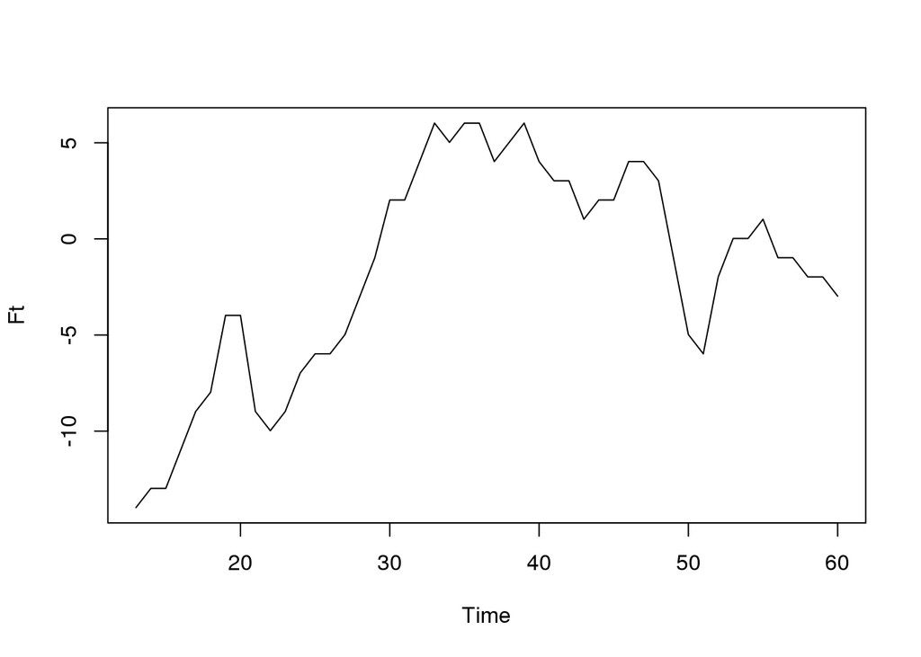

```r
Ft <- diff(Dt, lag = 12)
plot(Ft)
```

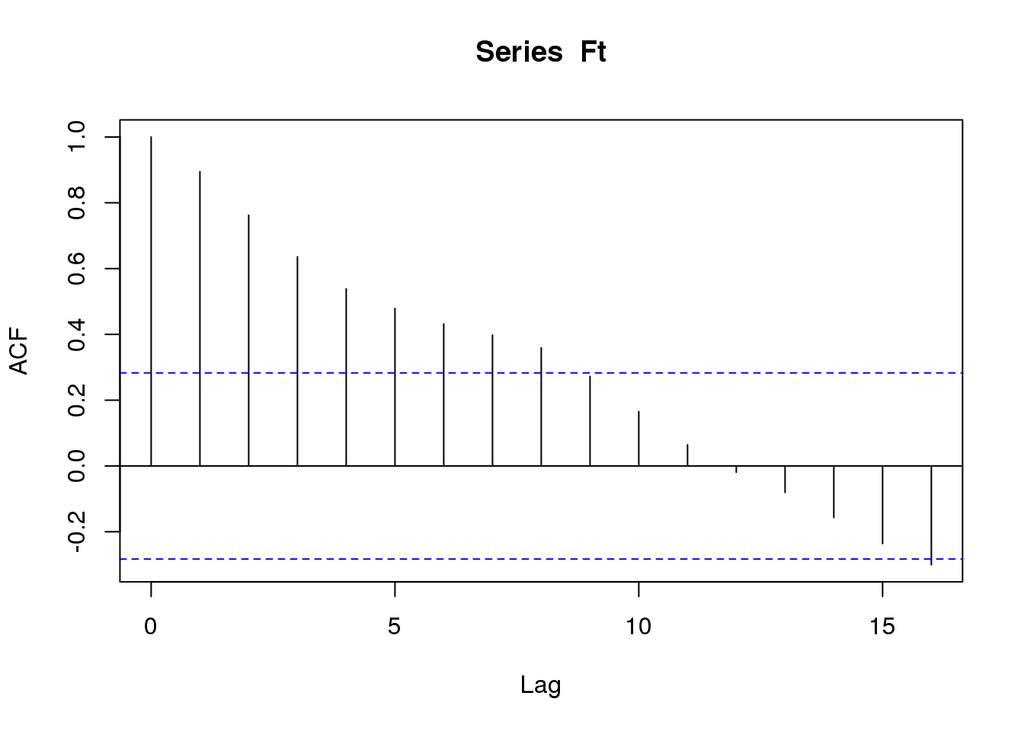

```r
acf(Ft)
```

**differencing does effectively remove the seasonality from the data**

6. Fit a trigonometric regression seasonal model to the de-trended trade data Dt and obtain the residuals. Create and describe the time series plot of the residuals (which can also be called seasonally adjusted de-trended data). Call this seasonally adjusted de-trended data St. Is St a white noise? Justify by attaching and discussing its correlogram.

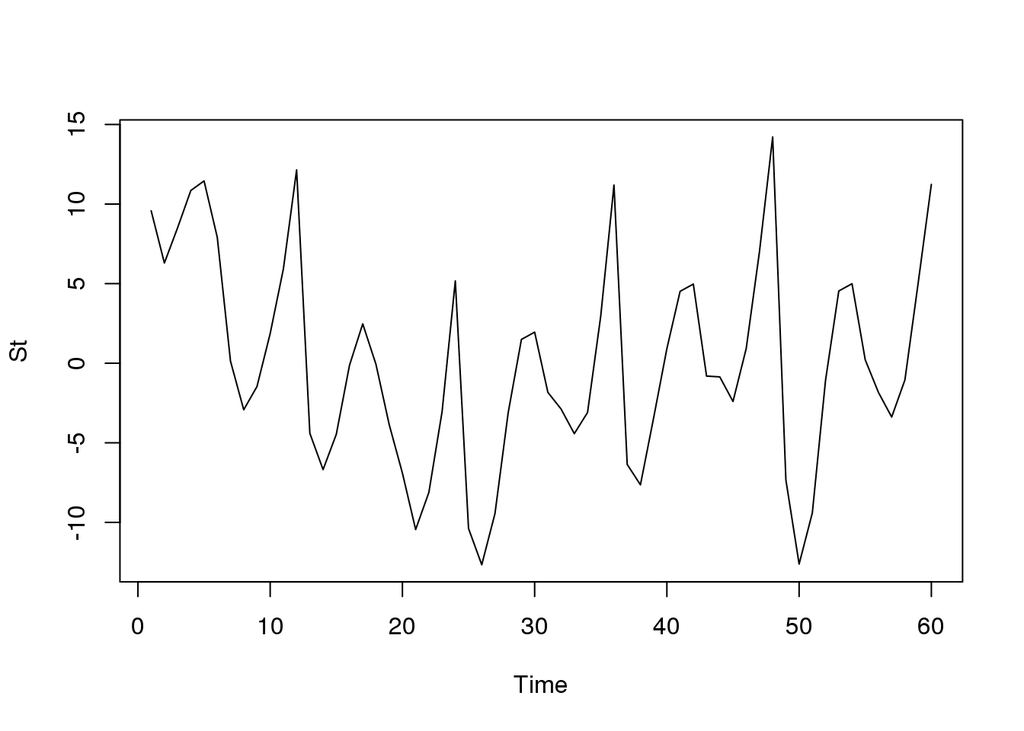

```r
X1 <- sin(2*pi*t/12)
X2 <- cos(2*pi*t/12)
mod3 <- lm(Dt ~ X1 + X2)
rres6 <- mod3$residuals

St <- ts(rres6)
plot.ts(St)
```

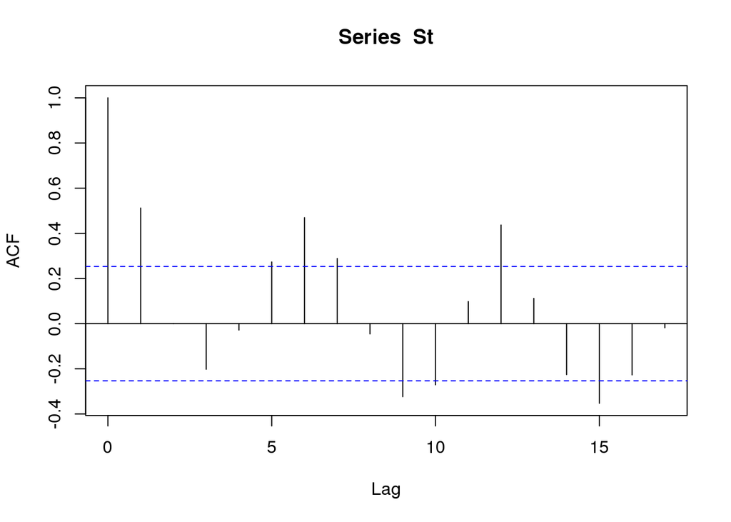

```r
acf(St)
```

**St is not white noise because the residuals still display seasonality**

7. What are the estimates of the beta parameters of the trigonometric seasonal regression model in #6? Which beta coefficient(s) is/are significant?

```r
summary(mod3)
```

```
##
## Call:
## lm(formula = Dt ~ X1 + X2)
##
## Residuals:
##      Min       1Q   Median       3Q      Max
## -12.6599  -3.9886  -0.8322   4.9793  14.2121
##
## Coefficients:
##               Estimate Std. Error t value Pr(>|t|)
## (Intercept) -2.420e-16  8.642e-01   0.000    1.000
## X1          -6.995e+00  1.222e+00  -5.723 4.06e-07 ***
## X2           8.863e-01  1.222e+00   0.725    0.471
## ---
## Signif. codes:  0 '***' 0.001 '**' 0.01 '*' 0.05 '.' 0.1 ' ' 1
##
## Residual standard error: 6.694 on 57 degrees of freedom
## Multiple R-squared:  0.3687, Adjusted R-squared:  0.3465
## F-statistic: 16.64 on 2 and 57 DF,  p-value: 2.03e-06
```

**-2.42030610^{-16}, -6.9952782, 0.8863453 The sin coefficient is significant while the cos coefficient is not**

8. Discuss the result of the F-test from fitting the trigonometric seasonal regression model. Is the model significant?  
   **we can see the F-test from the summary of mod3 gives the F-stat *16.64* and the model is significant because the p-value is *2.03e-06*.**
9. Discuss how well the trigonometric seasonal regression model fit the de-trended trade data.  
   **It is significant because the p-value of the F statistic is below the .05 threshold.**
10. Forecast the number of employed individuals for month 61 by first using the trigonometric seasonal regression model in #6 and then using the linear regression model in #2. (Hint: Forecast D61 first then use appropriate back-transformations to get Y61)

```r
library(forecast)
Linear <- 313.9887+(1.16485*61)
forecast(Dt)
```

```
##    Point Forecast        Lo 80    Hi 80       Lo 95    Hi 95
## 61       12.11993   3.60339222 20.63648  -0.9049932 25.14486
## 62       12.11993   0.07632708 24.16354  -6.2991738 30.53904
## 63       12.11993  -2.63016610 26.87004 -10.4383979 34.67827
## 64       12.11993  -4.91187269 29.15174 -13.9279670 38.16784
## 65       12.11993  -6.92210964 31.16198 -17.0023591 41.24223
## 66       12.11993  -8.73951021 32.97938 -19.7818335 44.02170
## 67       12.11993 -10.41078725 34.65066 -22.3378311 46.57770
## 68       12.11993 -11.96637721 36.20625 -24.7169007 48.95677
## 69       12.11993 -13.42742155 37.66729 -26.9513752 51.19125
## 70       12.11993 -14.80931336 39.04918 -29.0647963 53.30467
```

```r
Residual <- 12.11993

Prediction <- Linear + Residual
Prediction
```

```
## [1] 397.1645
```

# residual prediction + linear prediction = prediciton of the actual value

Upload the resulting .html document in AsULearn by midnight on Tuesday, Sep. 12, 2017 with the last names of your group members as part of the file name. Upload only one document for your group.